# Interpreting Correlations

This is a learning exercise that teaches you how to analyze correlations within mixed data sets. In this exercise we will study the following:

1. Types of variables as they relate to statistics.
2. What correlation metrics are common.
3. Interpretation of correlation metrics.

## Variable Types

### 1. Numerical

Numerical values fall within two categories:

1. Discrete - the values are confined to a certain limit and are integers. An example could be a binary value consisting of 0/1.
2. Continuous - these values can be divided in a way to construct different scales to look at subpopulations. For example, a measurement of age within a population provides continuous values. When you are looking into the subpopulations within that data set, you can simply create custom ranges (ages 1 through 10) to look at distributions.

**Here is some code to look at how these values look given their distribution:**

```python
%matplotlib inline

import numpy as np
import seaborn as sns
import pandas as pd
```

```python
N = 1000

# Generate N random binary values
random_binary = np.random.choice([0, 1], size=(N,))

# Generate N random ages from 0 to 100
random_ages = np.random.randint(0, 100, N)
```

```
mean 0.514
```

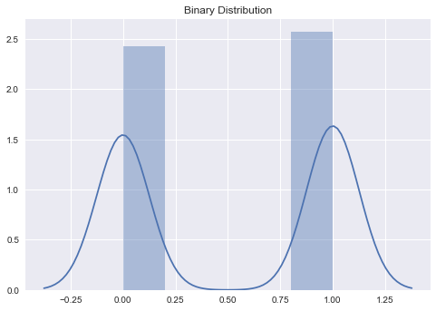

```python
# Plot binary distribution
ax = sns.distplot(random_binary)
ax.set_title('Binary Distribution')
print('mean', np.mean(random_binary))
```

The binary distribution has a mean of around 50%. As you provide more samples, you will see it converge closer to the mean (see [Central Limit Thereom](https://en.wikipedia.org/wiki/Central_limit_theorem)). The samples consist of an almost equal distribution of 0's and 1's for values.

```
mean 50.326
```

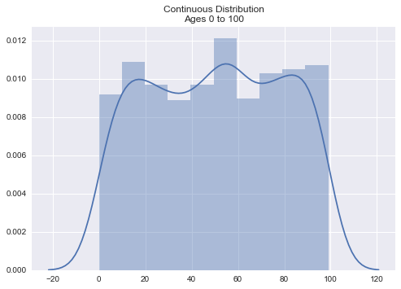

```python
# Plot age distribution
ax = sns.distplot(random_ages)
ax.set_title('Continuous Distribution\nAges 0 to 100')
print('mean', np.mean(random_ages))
```

Due to the range of values that we chose, the mean will converge at around 50. However, you can see that the distribution looks a much different than the binary distribution. This is due to the variability in the values.

### 2. Categorical

These types of numbers are simply used to group specific samples. They do not provide any mathematical meaning. For example, a 1 for male and 2 for female does not provide any importance.

### 3. Ordinal

Categorical values that provide weight with their meanings. It is essentially a mix of numerical and categorical values. For example, a ranking system.

For a race you can think of the following as individuals are given prizes:

- 1st place
- 2nd place
- 3rd place

or

A pain chart provided at a hospital in which 1 through 10 expresses the amount of pain you are experiencing.

## Common Correlation Metrics

### 1. Pearson

The Pearson Correlation Coeffecient measures the relationship of variables in a linear fashion on an X and Y coordinate system. The values range from -1 to +1. When the value is closest to -1, the relationship is negatively correlated. When the value is closest to +1, the relationship is positively correlated. Having a value close to 0 means that there is no significant correlation between X and Y.

[Read more here.](https://en.wikipedia.org/wiki/Pearson_correlation_coefficient)

Below we look at comparing age to salary with values that create a strong positive correlation.

```python
ages = [18, 18, 25, 27, 30, 38]
wages = [18000, 24000, 55000, 61000, 65000, 88000]

df = pd.DataFrame({'ages': ages, 'wages': wages})
```

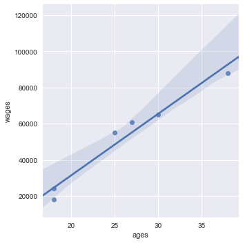

```python
sns.lmplot('ages', 'wages', data=df)
```

```python
df.corr()
```

|  | ages | wages |
| --- | --- | --- |
| ages | 1.00000 | 0.97941 |
| wages | 0.97941 | 1.00000 |

You can see that these variables have a strong positive correlation. They are very close to 1.

### 2. Spearman

The Spearman Rank Order Correlation measures the relationship of ordinal, interval or ratio variables. These values must be monotonic in nature. Essentially the variables both decrease or increase together.

[Read more here.](https://statistics.laerd.com/statistical-guides/spearmans-rank-order-correlation-statistical-guide.php)

```python
x = np.arange(0, 100)
x2 = np.arange(1, 5)
y = (1/4) * (x**2)
y2 = np.exp(-x2)
y3 = np.sin(x / 5)
```

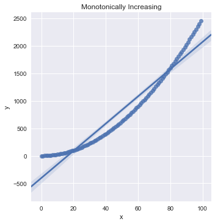

```python
# Plot increasing relation

df = pd.DataFrame({'x': x, 'y': y})
ax = sns.lmplot('x', 'y', data=df)
sns.plt.title('Monotonically Increasing')
```

```python
df.corr(method='spearman')
```

|  | x | y |
| --- | --- | --- |
| x | 1.0 | 1.0 |
| y | 1.0 | 1.0 |

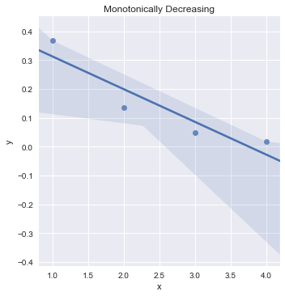

```python
# Plot decreasing relation

df = pd.DataFrame({'x': x2, 'y': y2})
ax = sns.lmplot('x', 'y', data=df)
sns.plt.title('Monotonically Decreasing')
```

```python
df.corr(method='spearman')
```

|  | x | y |
| --- | --- | --- |
| x | 1.0 | -1.0 |
| y | -1.0 | 1.0 |

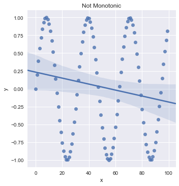

```python
# Plot no relation

df = pd.DataFrame({'x': x, 'y': y3})
ax = sns.lmplot('x', 'y', data=df)
sns.plt.title('Not Monotonic')
```

```python
df.corr(method='spearman')
```

|  | x | y |
| --- | --- | --- |
| x | 1.000000 | -0.172841 |
| y | -0.172841 | 1.000000 |

### 3. Biserial

A Point-biserial correlation consists of a binary variable and a non-binary variable. It is the same computation as the Pearson correlation with the exception of having a binary variable.

[Read more here.](https://en.wikipedia.org/wiki/Point-biserial_correlation_coefficient)

Let's create a distribution where you become obese as you get older.

```python
# Create some values
obese = [0, 0, 0, 0, 0, 0, 1, 1, 1, 1]
ages = [10, 20, 30, 35, 40, 45, 50, 55, 60, 70]

df = pd.DataFrame({'obese': obese, 'age': ages})
```

```python
df.corr()
```

|  | age | obese |
| --- | --- | --- |
| age | 1.00000 | 0.80615 |
| obese | 0.80615 | 1.00000 |

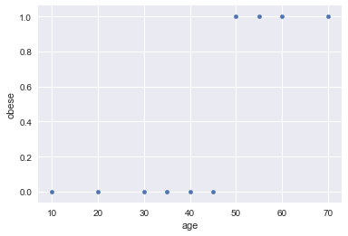

```python
df.plot.scatter('age', 'obese')
```